# Clarification of 2D Monte Carlo simulations

```r
library(tidyverse)
library(biorisk)
```

Despite being the go-to method for including variability and uncertainty in QMRA, 2D-Monte Carlo simulations can be hard to define and interpret. This document explains the approach that **biorisk** uses for this methodology. In order to avoid surprises, we also set up the seed of the p-rng.

```r
set.seed(412)
```

## Variability only

As a first step, let’s define a normal distribution. For simplicity, we will consider that this defines some type of variability. So, we will call it just “variability”:

```r
normal_variability <- Normal$new("variability")
```

This distribution has two parameters (`mu` and `sigma`). For starters, we will assign constant to both of them.

```r
normal_variability$
  map_input("sigma", Constant$new("sigma", .1))$
  map_input("mu", Constant$new("mu", 0))
```

Once we have defined the model, we can get 10,000 Monte Carlo simulations

```r
normal_variability$simulate(10000)
```

and visualize them as a density plot

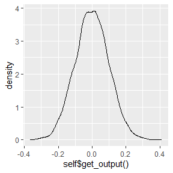

```r
normal_variability$density_plot()
```

## Uncertainty

```r
uniform_uncertainty <- Uniform$new("uncertainty")
```

This distribution has two parameters. We assign constants to both of them:

```r
uniform_uncertainty$
  map_input("min", Constant$new("min", -.5))$
  map_input("max", Constant$new("max", .5))
```

We can simulate this distribution and visualize it as a density plot.

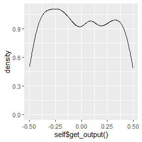

```r
uniform_uncertainty$simulate(1000)
uniform_uncertainty$density_plot()
```

## Variability and uncertainty together and not separated

Right now, both our distributions are independent. That is not what we want. We want “uncertainty” to describe the uncertainty of the expected value of “variability” (`mu`). We can do that by “mapping the input” `mu` to our `uniform_uncertainty`

```r
normal_variability$
  map_input("mu", uniform_uncertainty)
```

so we now have a linked model

```r
plot_model(normal_variability)
```

[output not shown]

[interactive chart not shown]

We can now simulate the model as we did before to get 10,000 Monte Carlo simulations that combine the variability (normal distribution) with the uncertainty (uniform distribution for the expected value).

```r
normal_variability$simulate(10000)
```

If we do a density plot

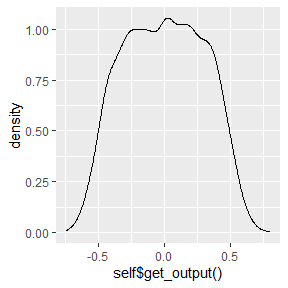

```r
normal_variability$density_plot()
```

we observe that both distributions have been combined. Instead of the typical bell curve, we see that there is a “flat top”. This is due to the uncertainty in the expected value.

Therefore, these simulations combine the variability and the uncertainty. However, we cannot separate between them.

## 2D Monte Carlo

This separation is accomplished using 2D Monte Carlo. In **biorisk**, this is done by adding a `level` to the definition of the probability distribution. Distributions on the “uncertainty” level are `level = 1` and those in the variability level are `level = 0`.

It is more convenient to define the uncertainty distributions first. Therefore, we define our `uniform_uncertainty`. Please note the addition of `level = 1`:

```r
uniform_uncertainty <- Uniform$new("uncertainty", level = 1)
```

Apart from that, the mapping of the inputs is identical as for the 1D Monte Carlo.

```r
uniform_uncertainty$
  map_input("min", Constant$new("min", -.5))$
  map_input("max", Constant$new("max", .5))
```

Next, we define our variability distributions. Please note the addition of `level = 0`:

```r
normal_variability <- Normal$new("variability", level = 0)
```

Again, the mapping of the inputs is identical regardless of whether calculations are 1D or 2D:

```r
normal_variability$
  map_input("sigma", Constant$new("sigma", .1))$
  map_input("mu", uniform_uncertainty)
```

We can plot the model to see that we have built the same dependencies:

```r
plot_model(normal_variability)
```

[interactive chart not shown]

In fact, even if we have defined variability and uncertainty separately, we can still make the simulations as 1D Monte Carlo (small differences in the contour are due to lack of convergence):

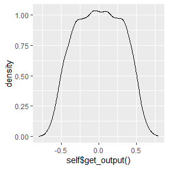

```r
normal_variability$simulate(10000)
normal_variability$density_plot()
```

But, again, those simulations do not separate between variability and uncertainty. To make that separation, we need to use `$simulate_2D()`. This method takes two arguments. The first one is the number of MC iterations in level 0 and the second the number of iterations in level 1. This difference will be clear in a second, so we first call the function with 500 and 200 iterations.

```r
normal_variability$simulate_2D(500, 200)
```

So… what did just happen? When we use `$simulate()`, **biorisk** creates a large table where each row is a MC iteration:

```r
normal_variability$simulations %>% head()
```

```
#> # A tibble: 6 × 3
#>        mu sigma       x
#>     <dbl> <dbl>   <dbl>
#> 1  0.493    0.1  0.397
#> 2 -0.453    0.1 -0.215
#> 3 -0.144    0.1 -0.106
#> 4 -0.228    0.1 -0.161
#> 5  0.0818   0.1  0.0102
#> 6  0.446    0.1  0.416
```

When we use `$simulate_2D()`, **biorisk** creates instead an array. That is just a fancy word for a table with extra dimensions. The results are saved in `$simulations_multi` and we can see that each one of its entries looks like a normal Monte Carlo simulation. For instance, this is the first one:

```r
normal_variability$simulations_multi[[1]] %>% head()
```

```
#> # A tibble: 6 × 3
#>      mu sigma     x
#>   <dbl> <dbl> <dbl>
#> 1 0.428   0.1 0.392
#> 2 0.428   0.1 0.433
#> 3 0.428   0.1 0.408
#> 4 0.428   0.1 0.430
#> 5 0.428   0.1 0.265
#> 6 0.428   0.1 0.453
```

and this is the second one:

```r
normal_variability$simulations_multi[[2]] %>% head()
```

```
#> # A tibble: 6 × 3
#>       mu sigma      x
#>    <dbl> <dbl>  <dbl>
#> 1 -0.433   0.1 -0.550
#> 2 -0.433   0.1 -0.571
#> 3 -0.433   0.1 -0.536
#> 4 -0.433   0.1 -0.669
#> 5 -0.433   0.1 -0.436
#> 6 -0.433   0.1 -0.378
```

If we play a closer look, we see that each one of those tables has 500 rows

```r
normal_variability$simulations_multi[[2]] %>% nrow()
```

```
#> [1] 500
```

and if we count them, we see there are 200

```r
normal_variability$simulations_multi %>% length()
```

```
#> [1] 200
```

Those numbers sound familiar, right? That’s because they are the number of iterations that we defined when we called `$simulate_2D(500, 200)`.

So, what is happening behind the curtains?

For each simulation in the uncertainty level, we can simulate values from each distribution defined at (`level = 1`). Then, using those values, we do a whole Monte Carlo simulations for those distributions at (`level = 0`), considering the dependencies. This is clear if we look at the first uncertainty iteration for `uniform_uncertainty`:

```r
uniform_uncertainty$simulations_multi[[1]] %>% head()
```

```
#> # A tibble: 6 × 3
#>     min   max     x
#>   <dbl> <dbl> <dbl>
#> 1  -0.5   0.5 0.428
#> 2  -0.5   0.5 0.428
#> 3  -0.5   0.5 0.428
#> 4  -0.5   0.5 0.428
#> 5  -0.5   0.5 0.428
#> 6  -0.5   0.5 0.428
```

Even though it is a distribution, every row has exactly the same value (0.43). That is due to the rows within the table representing the variability iterations. Because `uniform_uncertainty` is defined on the uncertainty level (`level = 1`), it does not vary in that dimension.

Now, if we look at the second uncertainty

```r
uniform_uncertainty$simulations_multi[[2]] %>% head()
```

```
#> # A tibble: 6 × 3
#>     min   max      x
#>   <dbl> <dbl>  <dbl>
#> 1  -0.5   0.5 -0.433
#> 2  -0.5   0.5 -0.433
#> 3  -0.5   0.5 -0.433
#> 4  -0.5   0.5 -0.433
#> 5  -0.5   0.5 -0.433
#> 6  -0.5   0.5 -0.433
```

The value also remains constant between rows, but it is a different one (-0.43). So, `uniform_uncertainty` varies between tables (uncertainty dimension), but not between rows (variability dimension).

On the other hand, `normal_variability` varies in both dimensions. If we look at the first uncertainty iteration

```r
normal_variability$simulations_multi[[1]] %>% head()
```

```
#> # A tibble: 6 × 3
#>      mu sigma     x
#>   <dbl> <dbl> <dbl>
#> 1 0.428   0.1 0.392
#> 2 0.428   0.1 0.433
#> 3 0.428   0.1 0.408
#> 4 0.428   0.1 0.430
#> 5 0.428   0.1 0.265
#> 6 0.428   0.1 0.453
```

we see that `x` (the output of the normal distribution) varies between rows, as is normal in every Monte Carlo simulation. Please note that both `mu` and `sigma` remain constant between rows (variability dimension). Why is that the case if `mu` is defined as a distribution? Because that distribution is in the uncertainty dimension (`level = 1`). In fact, the value remains constant at 0.43, which was the output of `uniform_uncertainty$simulations_multi[[1]]`.

In fact, if we look at the second uncertainty iteration

```r
normal_variability$simulations_multi[[2]] %>% head()
```

```
#> # A tibble: 6 × 3
#>       mu sigma      x
#>    <dbl> <dbl>  <dbl>
#> 1 -0.433   0.1 -0.550
#> 2 -0.433   0.1 -0.571
#> 3 -0.433   0.1 -0.536
#> 4 -0.433   0.1 -0.669
#> 5 -0.433   0.1 -0.436
#> 6 -0.433   0.1 -0.378
```

it matches `uniform_uncertainty$simulations_multi[[2]]`.

## Visualizing the results

The results of the 2D Monte Carlo simulation can be visualized using 2D cummulative plot

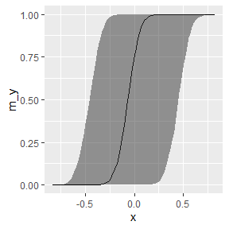

```r
normal_variability$cummulative_plot_2D()
```

In this plot, the solid line is the “variability distribution”. Then, the gray ribbon introduces the additional uncertainty due to the “uncertainty distributions”. This shows somehow the main hypothesis of 2D Monte Carlo. What we observe is a combination of variability and uncertainty. If we remove uncertainty, we have only variability, so we have “narrower” distributions. Theoretically, we could follow the opposite approach and remove variability to observe only uncertainty. However, for QMRA, we care more about variability than uncertainty, so we define models in this way because it is more convenient.

This philosophy is also evident if we look at the quantile table.

```r
quantile_table_2D(normal_variability,
                  probs = c(.5, .9),
                  chosen = c("variability", "uncertainty"))
```

```
#> # A tibble: 2 × 5
#>   node        `0.5_level1` `0.9_level1` `0.5_level0` `0.9_level0`
#>   <chr>              <dbl>        <dbl>        <dbl>        <dbl>
#> 1 uncertainty      -0.0698        0.358      -0.0698        0.358
#> 2 variability      -0.0623        0.375      -0.0684        0.360
```

The `uncertainty` element does not make a difference between variability and uncertainty dimensions. Therefore, its quantiles do not vary between both levels.

However, the `variability` element makes a difference. For that reason, the quantiles at `level = 0` are different from those at `level = 1`. In particular, the quantiles at `level = 1` are calculated as the quantiles of every simulation together. That is, binding every Monte Carlo simulation in the uncertainty dimension and calculating quantiles. On the other hand, the quantiles at `level = 0` are calculated independently for each iteration in the uncertainty dimension. Then, the values reported are the median of each quantile. Therefore, as a general rule, quantiles at `level = 1` should be wider than those at `level = 0`.